# STAD97PROJECT

Joanna(Yijing) Rong

July 22, 2016

Appendix - Data Organization

```r
#'Turn list of co/chronic mobidity and mental health into "ture" and "false"
#'
#' @param x the levels for patients in the original data frame to be turned into "ture" and "false"
#' @param possible numbers of possible levels for co/chronic mobidity and mental health
#' @return vectors of "ture" and "false" according to the levels of co/chronic mobidity and mental health
extractmorbidity=function(x,possible) #possible=#of possible values for 16 or 23 values for chronic / co-mobidity
{
  if(x[1]==999||is.na(x[1]))
  {
    return(rep(F,possible))
  }else{
    has=rep(F,possible)
    for(i in x){
      has[i]=T
    }
    return(has)
  }
}

hasrepeat=function(x,possible)
{
  tab=table(x)
  m=max(tab)
  w=names(which.max(tab))
  ifelse(m>1,w,NA)
}

#x=c(2,3,2,3,4)
#table(x)
#tab=table(t(data2[2,14:23]))
#tab["23"]

#'built a function that will count numbers of 23(mental health in comorbidity) in one patient
count23=function(x)
{
  tab=table(t(x))
  ans=ifelse(is.na(tab["23"]),0,tab["23"])
}

#count.discharged.status=function(x)
#{
  #tab=table(t(x))
  #ans=ifelse(is.na(tab["2"]),0,tab["2"])
#}

#'built a function that count the total numbers of actual mental health issue for each patient
countmh=function(x)
{
  return(sum(table(t(x))))
}



#made fuction that label the specific values of each co-mobidity
extractco=function(x)
{
  thenames=c("Other","Eating Disorders","Hypertension","Cardiovascular disease","Chronic kidney disease",
             "Retinopathy or Other eye disease"," Non-healing wounds (greater than 3 months)","Neuropathy","Liver disease (fatty liver)",
             "Peripheral vascular disease","Obesity (BMI > 30)","Current malignancy/cancer treatment","Hyperlipidemia",
             "Thyroid disease (other endocrinopathies POCT, Cushings)","Dementia","Pulmonary disease (COPD, Asthma)","Obstructive sleep apnea",
             "HIV/AIDS","Pancreas Diseases","Celiac Disease","Genetic Syndromes","Deafness and/or Blindness","Mental health")
  M=extractmorbidity(x,23)
  names(M)=thenames
  return(M)

}

#made functionthat label the specific values for each chronic-morbidity
extractchronic=function(x)
{
  thenames=c("Other(Chronic)","Neuropathy","Retinopathy","Blindness","Cardiovascular disease(Chronic)","Wounds (non-healing)",
             "Amputation","Skin conditions (cutaneous manifestations)","Lipohypertrophy","Hypoglycemia unawareness",
             "Diabetic myonecrosis","Foot problems (Charcot’s)","Stiff man’s syndrome","Hearing impairment","Fractures","Nephropathy")
  M=extractmorbidity(x,16)
  names(M)=thenames
  return(M)
}

extractMH=function(x)
{
  thenames=c("Depressive Disorder","Obsessive-compulsive and related disorders","Schizophrenia spectrum and other psychotic disorders",
             "Substance-related and addictive disorders","Bipolar Disorders","Anxiety disorders",
             "Neurodevelopmental disorder","Trauma and Stress-related disorders","Personality Disorders","Feeding and Eating Disorders",
             "Sleep-wake disorders","Type Unspecified")

  possible=12
  if(is.na(x[1]))
  {
    y=rep(F,possible)
  }else{
    has=rep(F,possible)
    for(i in x){
      if(!is.na(i)){
        has[i]=T
      }
    }
    y=has
  }
  names(y)=thenames
  return(y)
}



#'function that capture non numeric values
TidyDDScode=function(x){
  y=as.character(x)
  z=as.numeric(y)
  code=ifelse(is.na(z),y,ifelse(z<20,"numeric",y))
  return(code)
}

#'function that capture numeric values that are below 20
TidyDDSnumbers=function(x){
  y=as.character(x)
  z=as.numeric(y)
  code=ifelse(is.na(z),NA,ifelse(z<20,z,NA))
  return(code)
}


# read data in from csv
#
# a paragraph with more details about function
#
# @param file.name name of imported file
#
# @return dataframe containing all variables as appropriatly dates, factor and logicals
# @export
# @import dplyr
# @import lubridate
suppressMessages(library(dplyr))
Readdata=function(file.name)
{
  data=read.csv("inst/extdata/20160715.csv",header=T)
  #refer the column names by numbers

  #take the rows that are not NA for location and gender
  #cut = converted the numbers into factors --> converted the numbers to factors of the following variables
  #library(dplyr)
  data %>%
    dplyr::slice(1:622) ->data2


  locationf=cut(data2[,2],breaks=c(0,1.2,3),labels=c("HALTON","MISSISSAUGA"))


  genderf=cut(data2[,4],breaks=c(0,1.5,3),labels=c("M","F"))

  agef=cut(data2[,3],breaks=c(17,45,65,80,95))

  repeatreferral=cut(data2[,7],breaks=c(-1,0.5,2),labels=c("No","Yes"))


  referralfrom=cut(data2[,8],breaks=c(-1,1.5,2.5,3.5,4.5,6),labels=c("primary","self","specialist","hospital","DEC"))


  socialissue=cut(data2[,9],breaks=c(0,1.5,2.5,3.5,4.5,5.5,6.5,7.5,8.5,9.5,11,1000),
                  labels=c("social","community","income","elderly","smoke","drugs","housing","mobility","language","education","none"))
  #consider changing the short names to the actual names

  profcareplan=cut(data2[,64],breaks=c(-1,0.5,2,1000),labels=c("No","Yes","N/A"))


  SelfMGoals=cut(data2[,65],breaks=c(-1,0.5,2,1000),labels=c("No","Yes","N/A"))


  ExtentSelfM=cut(data2[,66],breaks=c(-1,0.5,1.5,2.5,3.5,1000),labels=c("None","Some","Most","All","N/A"))


  Pdischwithtrans=cut(data2[,67],breaks=c(-1,0.5,2,1000),labels=c("No","Yes","N/A"))


  DischSt=cut(data2[,69],breaks=c(0,1.5,2.5,3.5),labels=c("withdrawal","discharged","death"))


  Endorefer=cut(data2[,87],breaks=c(-1,0.5,2),labels=c("no","yes"))


  #extract the dates and truned them into Rdate
  #obtain different duration between admit date and discharge date

  #library(lubridate)
  referdate=lubridate::dmy(data2[,6])


  admitdate=lubridate::dmy(data2[,34])


  dischargedate=lubridate::dmy(data2[,68])



  #dis - data2[,73] #column 73 is numbers of weeeks between admitdate and discharge date as calculated in spreadsheet
  #summary(as.numeric(dis) - data2[,73])  #checking if the calculation is consisting
  #column Bu- Time in CCDC doesn't appear in the final spread sheet

  #co-mo is from column 14-23
  #chronic comlication is from column 24-33

  #made the function for "T=pts has both morbidity and F=pts doesn't have morbidity"


  como=t(apply(data2[,14:23],1,extractco))
  comorep=apply(data2[,14:23],1,hasrepeat)
  comorep
  which(comorep=="3")
  comomhrep=apply(data2[,14:23],1,count23)
  comomhrep #'counted numbers of "23" for each patient among the comorbidity columns --> fixed: no patients has repeated 23 any more!

  which(comomhrep>1) #' no patients are found that has more than one 23
  actualmhrep=apply(data2[,74:78],1,countmh)
  actualmhrep #'counted numbers of actual mental health issue for each patient among the mental health sections
  table(comomhrep>=1,actualmhrep>=1)
  which(comomhrep>=1 & actualmhrep==0) # not an issue any more--> pt354 doesn't have any mental healthy diagnosis listed, but has 23 coded in the comorbidity section

  table(comorep) #show which coded comorbidity has repeates --> only code "1" is repeated, but agree on ignoring it (also row61 has more 22 twice, but it's all good! )
  which(!is.na(comorep)) #shows which patients has more than one unique code
  #only co-morbidity has a lot of repeats

  chronic=t(apply(data2[,24:33],1,extractchronic))
  chronicrep=apply(data2[,24:33],1,hasrepeat)
  chronicrep
  table(chronicrep)
  #no repeats are found in chronic complications

  MH=t(apply(data2[,74:78],1,extractMH))
  head(MH)
  MHrep=apply(data2[,74:78],1,hasrepeat)
  MHrep
  table(MHrep)
  #no repeats found for MH diagnosis


  #make a new dataframe
  como=as.data.frame(como)
  chronic=as.data.frame(chronic)
  MH=as.data.frame(MH)
  dataframe=data.frame(locationf,age=data2[,3],genderf,agef,distance=data2[,5],referdate,repeatreferral,referralfrom,socialissue,
                       DDS.Emotional.burden.Enrollment=TidyDDSnumbers(data2[,10]),DDS.Emotional.burden.Enrollment.code=TidyDDScode(data2[,10]),
                       DDS.Physician.related.distress.Enrollment=TidyDDSnumbers(data2[,11]),DDS.Physician.related.distress.Enrollment.code=TidyDDScode(data2[,11]),
                       DDS.Regimen.related.distress.Enrollment=TidyDDSnumbers(data2[,12]),DDS.Regimen.related.distress.Enrollment.code=TidyDDScode(data2[,12]),
                       DDS.Interpersonal.distress.Enrollment=TidyDDSnumbers(data2[,13]),DDS.Interpersonal.distress.Enrollment.code=TidyDDScode(data2[,13]),
                       como,chronic,admitdate,data2[,35:39],admit.waist=as.numeric(as.character(data2[,40])),data2[,41:49],
                       DCweight=as.numeric(as.character(data2[,50])),
                       data2[,51:58],
                       DDS.Emotional.burden.Discharge=TidyDDSnumbers(data2[,59]),DDS.Emotional.burden.Discharge.code=TidyDDScode(data2[,59]),
                       DDS.Physician.related.distress.Discharge=TidyDDSnumbers(data2[,60]),DDS.Physician.related.distress.Discharge.code=TidyDDScode(data2[,60]),
                       DDS.Regimen.related.distress.Discharge=TidyDDSnumbers(data2[,61]),DDS.Regimen.related.distress.Discharge.code=TidyDDScode(data2[,61]),
                       DDS.Interpersonal.distress.Discharge=TidyDDSnumbers(data2[,62]),DDS.Interpersonal.distress.Discharge.code=TidyDDScode(data2[,62]),
                       data2[,63],profcareplan,
                       SelfMGoals,ExtentSelfM,Pdischwithtrans,dischargedate,DischSt,data2[,70:73],MH,data2[,79:86],Endorefer)
  return(dataframe)
}

dataframe=suppressWarnings(Readdata())
head(dataframe)
```

```
##   locationf age genderf    agef distance  referdate repeatreferral
## 1    HALTON  73       M (65,80]        6 2013-05-07             No
## 2    HALTON  60       F (45,65]       16 2013-05-10             No
## 3    HALTON  68       M (65,80]       18 2013-05-17             No
## 4    HALTON  66       F (65,80]       16 2013-04-29             No
## 5    HALTON  69       F (65,80]        6 2013-05-13             No
## 6    HALTON  67       M (65,80]        1 2013-05-21             No
##   referralfrom socialissue DDS.Emotional.burden.Enrollment
## 1      primary        none                             1.2
## 2      primary      social                             3.0
## 3      primary        none                             1.2
## 4      primary        none                             1.2
## 5      primary        none                             2.4
## 6         self        none                             4.6
##   DDS.Emotional.burden.Enrollment.code
```

[output cut: 370 more lines]

Data Analysis 1a.Numbers of male and female patients from each site

```r
outofregions <- table(dataframe$locationf,dataframe$genderf)
outofregions
```

```
##
##                 M   F
##   HALTON       87  69
##   MISSISSAUGA 257 209
```

```r
prop.table(outofregions,margin=1)
```

```
##
##                       M         F
##   HALTON      0.5576923 0.4423077
##   MISSISSAUGA 0.5515021 0.4484979
```

No effect of genders - same percentage of males and females from both regions

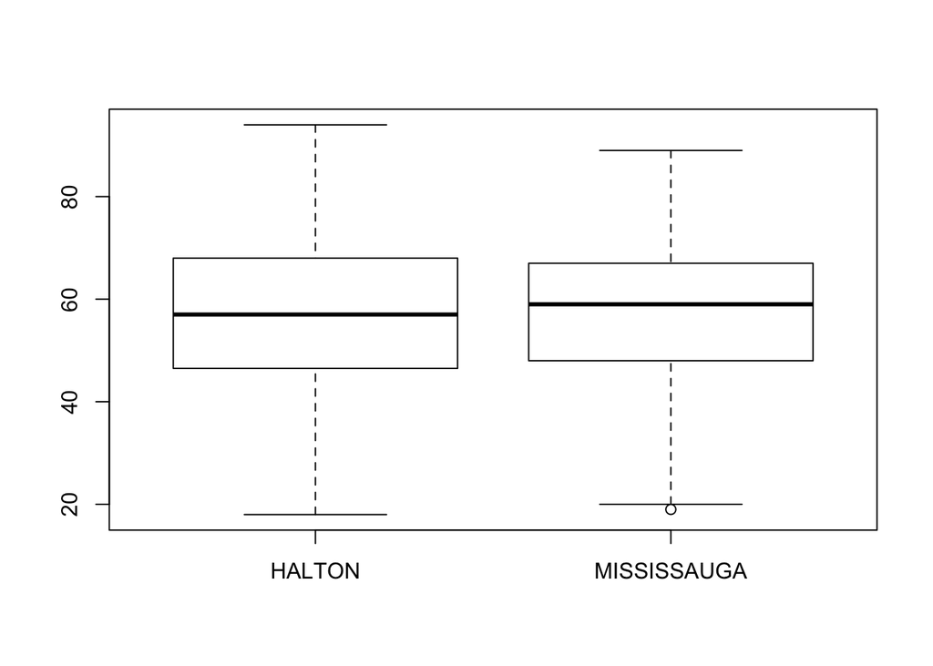

```r
boxplot(dataframe$age~dataframe$locationf)
```

Boxplot analysis suggest that there are no great difference in midian and spread for numbers of patients on both sites.

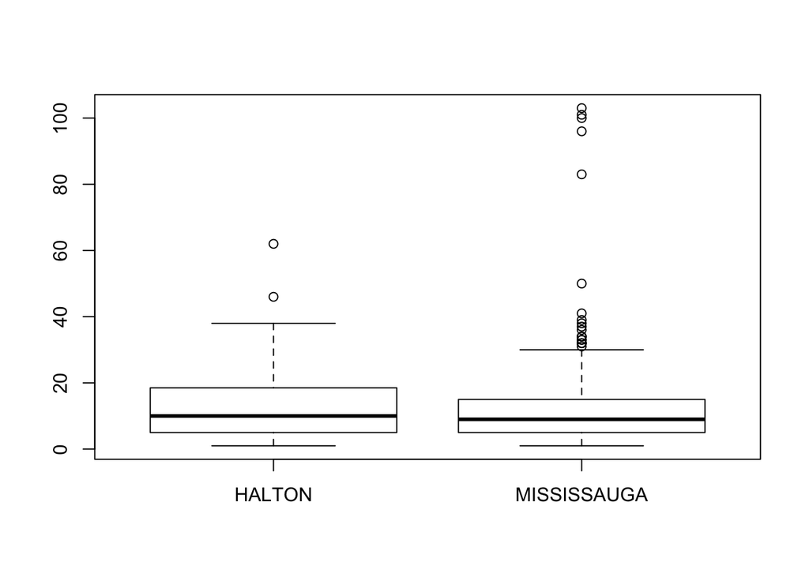

```r
boxplot(dataframe$distance~dataframe$locationf)
```

The median distance to both sites are very similarl; more poeple who need to travel longer distance tend to visit Mississauga site.

1b.numbers of patients with each social issue/range of social issues:

```r
socialissues <- table(dataframe$socialissue)
socialissues
```

```
##
##    social community    income   elderly     smoke     drugs   housing
##        38        11       100        29        40        20         3
##  mobility  language education      none
##        15        13        20       333
```

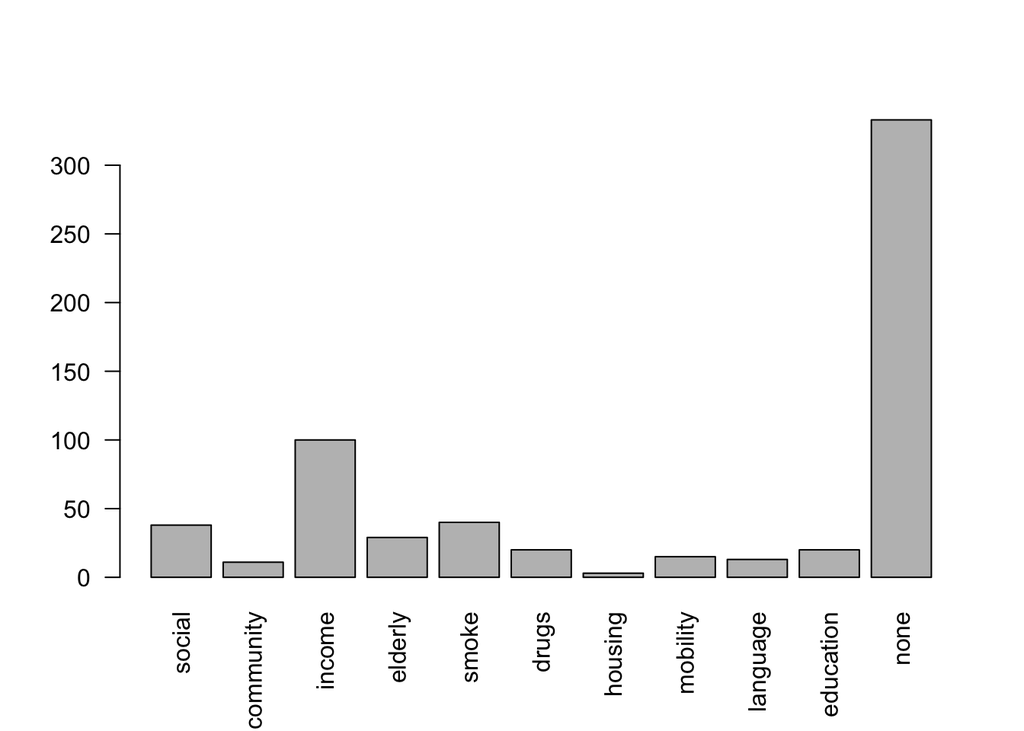

```r
plot(dataframe$socialissue,las=2)
```

Compare to the impactful issues you mentioned, the following social issues appears to be more frequent: low income, social support, smoking, elderly

```r
names(dataframe)
```

```
##   [1] "locationf"
##   [2] "age"
##   [3] "genderf"
##   [4] "agef"
##   [5] "distance"
##   [6] "referdate"
##   [7] "repeatreferral"
##   [8] "referralfrom"
##   [9] "socialissue"
##  [10] "DDS.Emotional.burden.Enrollment"
##  [11] "DDS.Emotional.burden.Enrollment.code"
##  [12] "DDS.Physician.related.distress.Enrollment"
##  [13] "DDS.Physician.related.distress.Enrollment.code"
##  [14] "DDS.Regimen.related.distress.Enrollment"
##  [15] "DDS.Regimen.related.distress.Enrollment.code"
```

[output cut: 106 more lines]

1c.numbers of patients with each co-morbidity

```r
avgcomo=subset(dataframe, select=c("Other","Eating.Disorders","Hypertension","Cardiovascular.disease","Chronic.kidney.disease","Retinopathy.or.Other.eye.disease","X.Non.healing.wounds..greater.than.3.months.",
                          "Neuropathy","Liver.disease..fatty.liver.","Peripheral.vascular.disease","Obesity..BMI...30.","Current.malignancy.cancer.treatment","Hyperlipidemia","Thyroid.disease..other.endocrinopathies.POCT..Cushings.","Dementia",
                             "Pulmonary.disease..COPD..Asthma.","Obstructive.sleep.apnea","HIV.AIDS","Pancreas.Diseases","Celiac.Disease","Genetic.Syndromes","Deafness.and.or.Blindness","Mental.health"))


library(tidyr)
library(dplyr)
avgcomo %>% gather(col,v,Other:Mental.health) %>% table()
```

```
##                                                          v
## col                                                       FALSE TRUE
##   Other                                                     391  231
##   Eating.Disorders                                          614    8
##   Hypertension                                              228  394
##   Cardiovascular.disease                                    481  141
##   Chronic.kidney.disease                                    555   67
##   Retinopathy.or.Other.eye.disease                          589   33
##   X.Non.healing.wounds..greater.than.3.months.              610   12
##   Neuropathy                                                600   22
##   Liver.disease..fatty.liver.                               606   16
##   Peripheral.vascular.disease                               584   38
##   Obesity..BMI...30.                                        322  300
##   Current.malignancy.cancer.treatment                       599   23
##   Hyperlipidemia                                            240  382
##   Thyroid.disease..other.endocrinopathies.POCT..Cushings.   551   71
##   Dementia                                                  604   18
##   Pulmonary.disease..COPD..Asthma.                          588   34
##   Obstructive.sleep.apnea                                   582   40
##   HIV.AIDS                                                  622    0
##   Pancreas.Diseases                                         610   12
##   Celiac.Disease                                            620    2
##   Genetic.Syndromes                                         621    1
##   Deafness.and.or.Blindness                                 608   14
##   Mental.health                                             436  186
```

1c.average # of co-morbidities

```r
sumofcomofoeachpt=apply(avgcomo,1,sum)
summary(sumofcomofoeachpt)
```

```
##    Min. 1st Qu.  Median    Mean 3rd Qu.    Max.
##   0.000   2.000   3.000   3.288   4.000  10.000
```

Each patients have average of 3 different co-morbidity

1c.numbers of patients with each chronic-morbidity

```r
avgchronic=subset(dataframe, select=c("Other.Chronic.","Neuropathy.1","Retinopathy","Blindness","Cardiovascular.disease.Chronic.","Wounds..non.healing.",
                             "Amputation","Skin.conditions..cutaneous.manifestations.","Lipohypertrophy","Hypoglycemia.unawareness",
                             "Diabetic.myonecrosis","Foot.problems..Charcot.s.","Stiff.man.s.syndrome","Hearing.impairment","Fractures","Nephropathy"))

avgchronic %>% gather(col,v,Other.Chronic.:Nephropathy) %>% table()
```

```
##                                             v
## col                                          FALSE TRUE
##   Other.Chronic.                               593   29
##   Neuropathy.1                                 467  155
##   Retinopathy                                  512  110
##   Blindness                                    615    7
##   Cardiovascular.disease.Chronic.              590   32
##   Wounds..non.healing.                         591   31
##   Amputation                                   615    7
##   Skin.conditions..cutaneous.manifestations.   607   15
##   Lipohypertrophy                              614    8
##   Hypoglycemia.unawareness                     606   16
##   Diabetic.myonecrosis                         622    0
##   Foot.problems..Charcot.s.                    615    7
##   Stiff.man.s.syndrome                         622    0
##   Hearing.impairment                           621    1
##   Fractures                                    622    0
##   Nephropathy                                  505  117
```

Highest frequency among chronic-morbidity:Neuropathy (155)

1c.average # of chronic-morbidities

```r
sumofchronicfoeachpt=apply(avgchronic,1,sum)
summary(sumofchronicfoeachpt)
```

```
##    Min. 1st Qu.  Median    Mean 3rd Qu.    Max.
##  0.0000  0.0000  0.0000  0.8601  1.0000  6.0000
```

Each pt have average 1 chronic-morbidity

1c.numbers of patients have mental health as co-morbidity:

```r
comomental <- table(dataframe$Mental.health)
comomental
```

```
##
## FALSE  TRUE
##   436   186
```

```r
which(dataframe$Mental)
```

```
##   [1]   2   7   9  10  11  26  27  31  32  38  40  41  46  52  56  69  78
##  [18]  80  85  87  94  96  97 104 110 112 122 123 124 127 128 134 135 150
##  [35] 159 161 166 167 169 170 174 176 178 181 190 195 197 198 199 200 204
##  [52] 207 208 210 213 215 227 230 232 241 248 249 251 253 257 259 261 265
##  [69] 266 270 272 273 274 277 279 284 285 291 292 293 295 302 303 316 317
##  [86] 320 324 325 327 329 330 332 340 342 344 345 352 356 357 361 367 368
## [103] 371 374 379 383 387 389 396 399 404 405 409 411 412 416 419 420 421
## [120] 424 425 426 430 432 433 437 446 452 456 457 463 467 468 469 470 475
## [137] 478 479 482 485 487 488 489 490 491 493 498 499 501 503 506 515 517
## [154] 521 524 525 530 531 533 536 538 542 547 550 555 556 558 561 565 568
## [171] 577 582 584 589 590 592 594 595 597 601 605 607 609 614 618 622
```

186 patients have mental health as one of their co-morbidity also provides informaiton about who are those patients

How many has mental health as one of the co-morbidities(regardingprotions of F and M)

```r
comomental <- table(dataframe$Mental.health,dataframe$genderf)
comomental
```

```
##
##           M   F
##   FALSE 260 176
##   TRUE   84 102
```

```r
prop.table(comomental,margin=2)
```

```
##
##                 M         F
##   FALSE 0.7558140 0.6330935
##   TRUE  0.2441860 0.3669065
```

Among Male, only 25% have mental health issues, but higher proportion of female than male have mental health issue

2a.comparing admit and discharged clinical metrics (A1C)

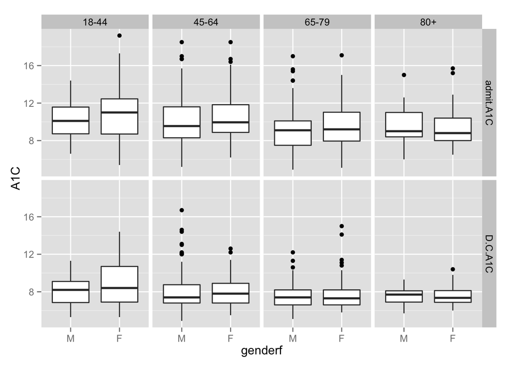

```r
library(dplyr)
library(tidyr)
library(ggplot2)
dataframe %>% gather(admitdischarge,A1C,c(admit.A1C,D.C.A1C)) %>%
  mutate(agef=cut(age,breaks=c(17,44,64,79,95),labels=c("18-44","45-64","65-79","80+"))) %>%
  ggplot(aes(x=genderf,y=A1C))+geom_boxplot()+facet_grid(admitdischarge~agef)
```

-discharged A1C values are substentically lower across all age groups than admit A1C level -Older patients tend to have lower admit and discharged A1C value compare to younger patients in general -not much genders effects as the changes of A1C values in males are similar as females -A1C values appears to decrease as age increase for both adimit and discharge

```r
dataframe %>% gather(admitdischarge,A1C,c(admit.A1C,D.C.A1C)) %>%
  mutate(agef=cut(age,breaks=c(17,44,64,79,95),labels=c("18-44","45-64","65-79","80+"))) %>% group_by(agef,genderf) %>%
  summarise(n=n())
```

```
## Source: local data frame [8 x 3]
## Groups: agef
##
##    agef genderf   n
## 1 18-44       M 108
## 2 18-44       F 118
## 3 45-64       M 344
## 4 45-64       F 250
## 5 65-79       M 194
## 6 65-79       F 146
## 7   80+       M  42
## 8   80+       F  42
```

This provides information about numbers of patients in each category to ensure that there are sufficient numbers of individual in each group to prevent bias. There are resonably large frequency for each age group - good thing

```r
dataframe %>% gather(admitdischarge,A1C,c(admit.A1C,D.C.A1C)) %>%
  filter(is.na(A1C)) %>% select(c(admitdischarge,A1C))
```

```
##    admitdischarge A1C
## 1       admit.A1C  NA
## 2       admit.A1C  NA
## 3         D.C.A1C  NA
## 4         D.C.A1C  NA
## 5         D.C.A1C  NA
## 6         D.C.A1C  NA
## 7         D.C.A1C  NA
## 8         D.C.A1C  NA
## 9         D.C.A1C  NA
## 10        D.C.A1C  NA
## 11        D.C.A1C  NA
## 12        D.C.A1C  NA
## 13        D.C.A1C  NA
## 14        D.C.A1C  NA
```

[output cut: 83 more lines]

```r
c=subset(dataframe, select=c("admit.A1C","D.C.A1C","DischSt"))
c
```

[output not shown]

[output cut: 608 more lines]

```r
c %>% gather(admitdischarge,A1C,c(admit.A1C,D.C.A1C)) %>% filter(is.na(A1C))
```

```
##       DischSt admitdischarge A1C
## 1       death      admit.A1C  NA
## 2  withdrawal      admit.A1C  NA
## 3  withdrawal        D.C.A1C  NA
## 4  withdrawal        D.C.A1C  NA
## 5  withdrawal        D.C.A1C  NA
## 6  withdrawal        D.C.A1C  NA
## 7  withdrawal        D.C.A1C  NA
## 8  withdrawal        D.C.A1C  NA
## 9  withdrawal        D.C.A1C  NA
## 10 withdrawal        D.C.A1C  NA
## 11      death        D.C.A1C  NA
## 12 withdrawal        D.C.A1C  NA
## 13 withdrawal        D.C.A1C  NA
## 14 withdrawal        D.C.A1C  NA
```

[output cut: 83 more lines]

Keep in mind that there are 97 missing A1C values in total (2 are from admited A1C); but all patients who have missing D.C.A1C are actually withdrew becuase of death/withdrawal, no missing data are found among those who discharged –> nothing to worry about!

2a.comparing admit and discharged clinical matrix(Lipids level(HDL cholesterol))

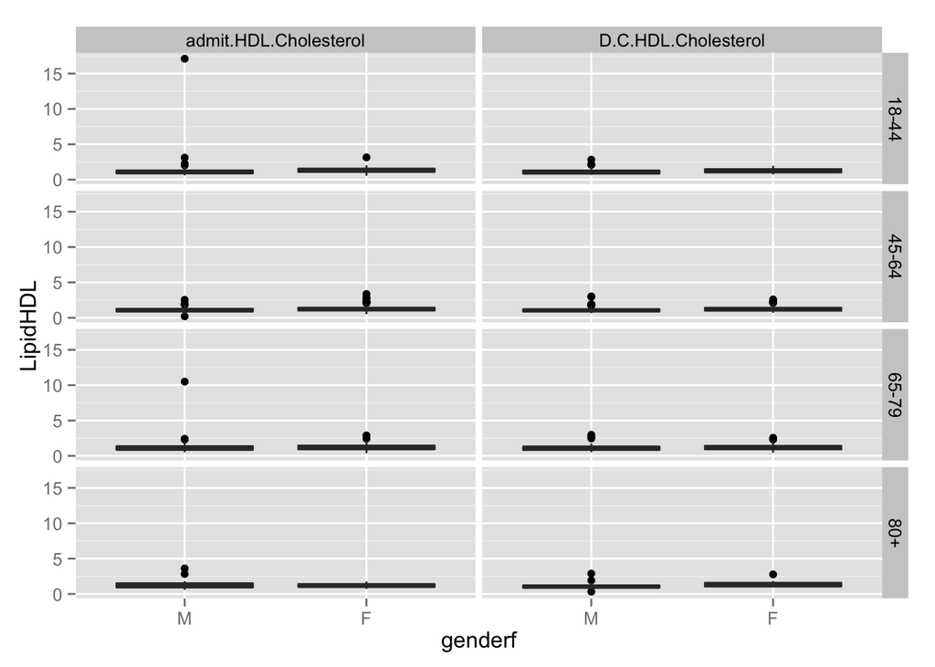

```r
dataframe %>% gather(admitdischarge,LipidHDL,c(admit.HDL.Cholesterol, D.C.HDL.Cholesterol)) %>%
  mutate(agef=cut(age,breaks=c(17,44,64,79,95),labels=c("18-44","45-64","65-79","80+")))->mutatea
  mutatea %>% ggplot(aes(x=genderf,y=LipidHDL))+geom_boxplot()+facet_grid(agef~admitdischarge)
```

added filter to select HDLlevel less than 3

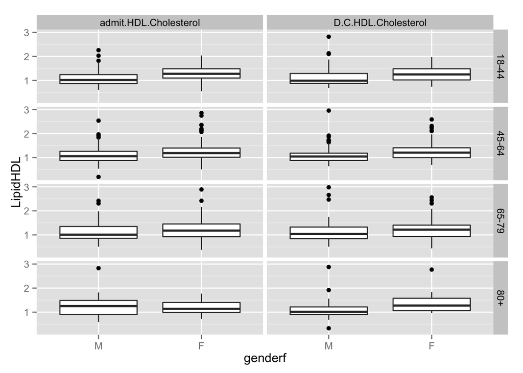

```r
mutatea %>% filter(LipidHDL<3) %>%
  ggplot(aes(x=genderf,y=LipidHDL))+geom_boxplot()+facet_grid(agef~admitdischarge)
```

summary of the data

```r
mutatea %>% group_by(admitdischarge,agef,genderf) %>% summarise(Q1=quantile(LipidHDL,0.25,na.rm=T),
    med=median(LipidHDL,na.rm=T),Q3=quantile(LipidHDL,0.75,na.rm=T),missing=sum(is.na(LipidHDL)),n=n())
```

```
## Source: local data frame [16 x 8]
## Groups: admitdischarge, agef
##
##           admitdischarge  agef genderf     Q1   med     Q3 missing   n
## 1  admit.HDL.Cholesterol 18-44       M 0.8900 1.030 1.3025       6  54
## 2  admit.HDL.Cholesterol 18-44       F 1.1000 1.280 1.5600      10  59
## 3  admit.HDL.Cholesterol 45-64       M 0.8850 1.060 1.2650       9 172
## 4  admit.HDL.Cholesterol 45-64       F 1.0225 1.190 1.4225       7 125
## 5  admit.HDL.Cholesterol 65-79       M 0.8600 1.010 1.3650       6  97
## 6  admit.HDL.Cholesterol 65-79       F 0.9250 1.180 1.4550       6  73
## 7  admit.HDL.Cholesterol   80+       M 0.9200 1.280 1.5100       0  21
## 8  admit.HDL.Cholesterol   80+       F 0.9900 1.140 1.4000       4  21
## 9    D.C.HDL.Cholesterol 18-44       M 0.8750 0.990 1.2900      16  54
## 10   D.C.HDL.Cholesterol 18-44       F 1.0200 1.250 1.4850      20  59
## 11   D.C.HDL.Cholesterol 45-64       M 0.8900 1.050 1.2100      39 172
## 12   D.C.HDL.Cholesterol 45-64       F 1.0000 1.210 1.4100      24 125
## 13   D.C.HDL.Cholesterol 65-79       M 0.8425 1.040 1.3275      11  97
## 14   D.C.HDL.Cholesterol 65-79       F 0.9325 1.220 1.4075      19  73
## 15   D.C.HDL.Cholesterol   80+       M 0.9000 1.015 1.2175       3  21
## 16   D.C.HDL.Cholesterol   80+       F 1.0600 1.275 1.5775       5  21
```

2a.comparing admit and discharged clinical matrix(Lipids level(LDL cholesterol))

```r
aggregate(cbind(admit.LDL.Cholesterol, D.C.LDL.Cholesterol)~genderf+agef,data=dataframe,mean)
```

```
##   genderf    agef admit.LDL.Cholesterol D.C.LDL.Cholesterol
## 1       M (17,45]              2.565771            2.248857
## 2       F (17,45]              2.535135            2.361351
## 3       M (45,65]              2.242578            1.998281
## 4       F (45,65]              2.512475            2.215248
## 5       M (65,80]              1.842267            1.714267
## 6       F (65,80]              2.197500            2.032292
## 7       M (80,95]              1.544286            1.353571
## 8       F (80,95]              2.413636            2.288182
```

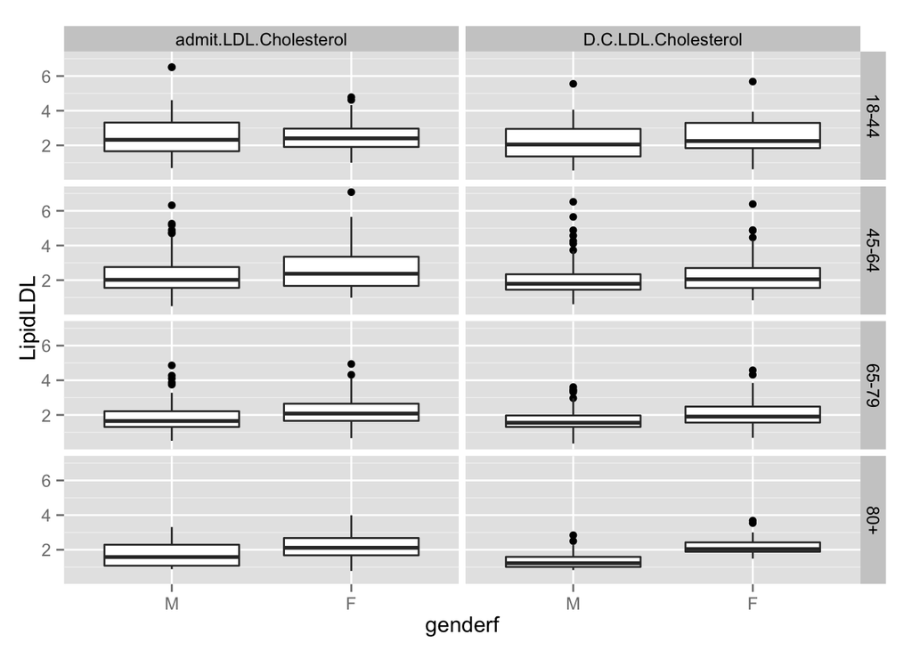

```r
dataframe %>% gather(admitdischarge,LipidLDL,c(admit.LDL.Cholesterol, D.C.LDL.Cholesterol)) %>%
  mutate(agef=cut(age,breaks=c(17,44,64,79,95),labels=c("18-44","45-64","65-79","80+"))) %>%
  ggplot(aes(x=genderf,y=LipidLDL))+geom_boxplot()+facet_grid(agef~admitdischarge)
```

The median of both admit and discharged LDL cholesterol level appear to be very similar, suggesting very minor treatment effect on this clinical matrix

2a.comparing admit and discharged clinical matrix(eGFR)

```r
aggregate(cbind(admit.eGFR, D.C.eGFR)~genderf+agef,data=dataframe,mean)
```

```
##   genderf    agef admit.eGFR D.C.eGFR
## 1       M (17,45]  100.34146 96.97561
## 2       F (17,45]   99.55814 98.83721
## 3       M (45,65]   80.70866 78.74055
## 4       F (45,65]   80.74490 79.87755
## 5       M (65,80]   61.97183 58.94366
## 6       F (65,80]   60.26667 58.11111
## 7       M (80,95]   64.15385 56.46154
## 8       F (80,95]   51.50000 49.00000
```

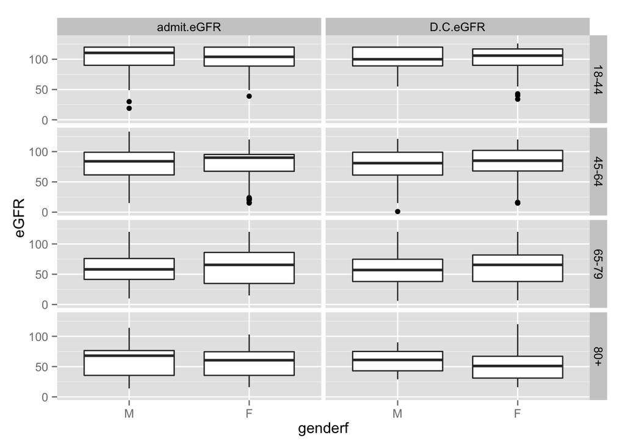

```r
dataframe %>% gather(admitdischarge,eGFR,c(admit.eGFR, D.C.eGFR)) %>%
  mutate(agef=cut(age,breaks=c(17,44,64,79,95),labels=c("18-44","45-64","65-79","80+")))->mutatea
  mutatea %>% ggplot(aes(x=genderf,y=eGFR))+geom_boxplot()+facet_grid(agef~admitdischarge)
```

-eGFR scores then to be lower as age increase -median of discharged eGFR value decrease substentically for male in age group 18-44

numerical summary of the data

```r
mutatea %>% group_by(admitdischarge,agef,genderf) %>% summarise(Q1=quantile(eGFR,0.25,na.rm=T),
    med=median(eGFR,na.rm=T),Q3=quantile(eGFR,0.75,na.rm=T),missing=sum(is.na(eGFR)),n=n())
```

```
## Source: local data frame [16 x 8]
## Groups: admitdischarge, agef
##
##    admitdischarge  agef genderf    Q1   med     Q3 missing   n
## 1      admit.eGFR 18-44       M 90.00 110.5 120.00       8  54
## 2      admit.eGFR 18-44       F 88.75 104.0 120.00       7  59
## 3      admit.eGFR 45-64       M 61.50  84.0  99.00      17 172
## 4      admit.eGFR 45-64       F 67.50  90.0  95.25      13 125
## 5      admit.eGFR 65-79       M 41.50  58.0  76.00      10  97
## 6      admit.eGFR 65-79       F 34.75  65.5  86.00      11  73
## 7      admit.eGFR   80+       M 35.50  68.0  76.50       2  21
## 8      admit.eGFR   80+       F 35.50  60.5  74.50       3  21
## 9        D.C.eGFR 18-44       M 89.00 100.0 120.00      13  54
## 10       D.C.eGFR 18-44       F 90.00 106.0 117.00      16  59
## 11       D.C.eGFR 45-64       M 61.25  81.0  99.00      38 172
## 12       D.C.eGFR 45-64       F 68.00  85.0 102.00      28 125
## 13       D.C.eGFR 65-79       M 38.00  57.0  74.75      19  97
## 14       D.C.eGFR 65-79       F 38.00  65.5  81.75      19  73
## 15       D.C.eGFR   80+       M 43.00  61.0  75.00       4  21
## 16       D.C.eGFR   80+       F 31.00  51.0  67.00       5  21
```

the treatment effect appears to be samll/non existent as the difference between admit and discharge across gender and age is consistent; however, there is age effect as as age increase, eGFR value decrease (At least for the first 3 age groups). there is no consistent gender effect.

2a.comparing admit and discharged clinical matrix(Micro Albumin)

```r
aggregate(cbind(admit.Micro.Albumin,D.C.Micro.Albumin)~genderf+agef,data=dataframe,mean)
```

```
##   genderf    agef admit.Micro.Albumin D.C.Micro.Albumin
## 1       M (17,45]            239.5875         155.08750
## 2       F (17,45]            295.5429          34.28286
## 3       M (45,65]            377.0250         678.12143
## 4       F (45,65]            291.6448         190.70034
## 5       M (65,80]            298.6588         299.12941
## 6       F (65,80]            138.2214         288.00714
## 7       M (80,95]            153.4500         129.92500
## 8       F (80,95]            164.8250          47.95000
```

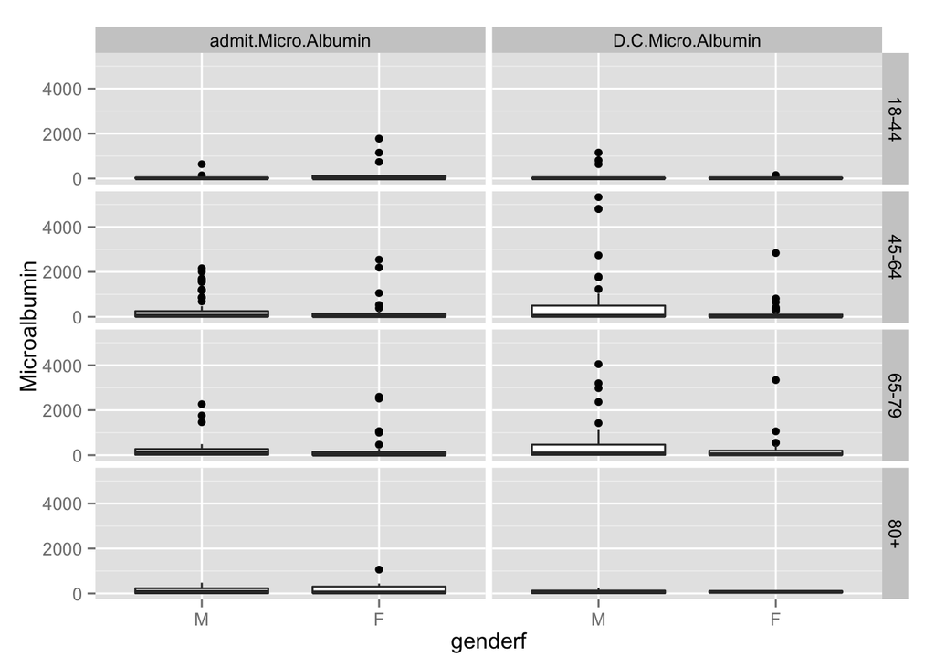

```r
dataframe %>% gather(admitdischarge,Microalbumin,c(admit.Micro.Albumin, D.C.Micro.Albumin)) %>%
  mutate(agef=cut(age,breaks=c(17,44,64,79,95),labels=c("18-44","45-64","65-79","80+"))) %>%
  ggplot(aes(x=genderf,y=Microalbumin))+geom_boxplot()+facet_grid(agef~admitdischarge)
```

need help

2c.Change in QoL index (emotional burden)

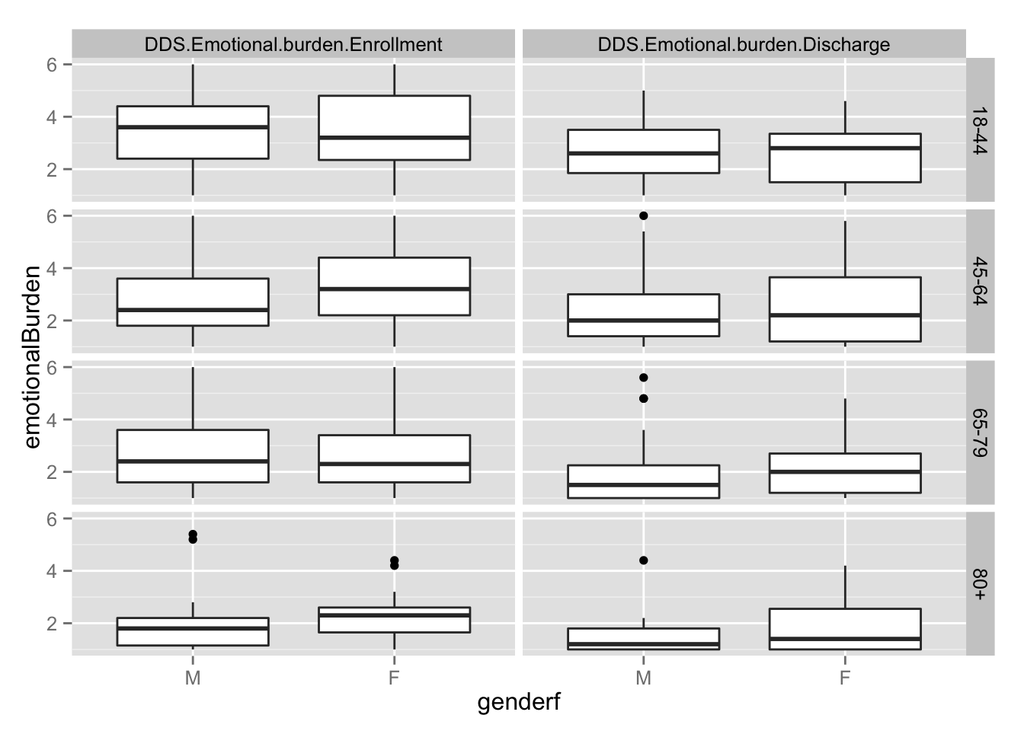

```r
dataframe %>% gather(admitdischarge,emotionalBurden,c(DDS.Emotional.burden.Enrollment,DDS.Emotional.burden.Discharge)) %>%
  mutate(agef=cut(age,breaks=c(17,44,64,79,95),labels=c("18-44","45-64","65-79","80+"))) %>%
  ggplot(aes(x=genderf,y=emotionalBurden))+geom_boxplot()+facet_grid(agef~admitdischarge)
```

-lower emotional burden discharge scores for both male and female -female tend to have higher emotional burden discharge scores than male for both admit and discharged measuremnt (except for female in age group 18-44 ) -the older the patients, the lower the emotional burden scores are measured

```r
dataframe %>% gather(admitdischarge,emotionalBurden,c(DDS.Emotional.burden.Enrollment,DDS.Emotional.burden.Discharge)) %>%
  mutate(agef=cut(age,breaks=c(17,44,64,79,95),labels=c("18-44","45-64","65-79","80+"))) %>% group_by(agef,genderf) %>%
  summarise(n=n())
```

```
## Source: local data frame [8 x 3]
## Groups: agef
##
##    agef genderf   n
## 1 18-44       M 108
## 2 18-44       F 118
## 3 45-64       M 344
## 4 45-64       F 250
## 5 65-79       M 194
## 6 65-79       F 146
## 7   80+       M  42
## 8   80+       F  42
```

This provides information about numbers of patients in each category to ensure that there are sufficient numbers of individual in each group to prevent bias. There are resonably large frequency for each age group - good thing

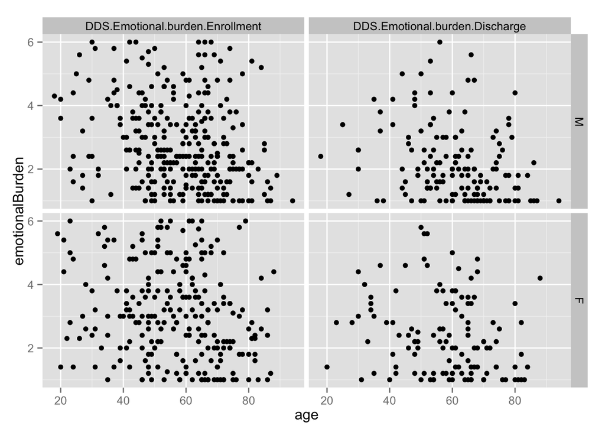

```r
dataframe %>% gather(admitdischarge,emotionalBurden,c(DDS.Emotional.burden.Enrollment,DDS.Emotional.burden.Discharge)) %>%
  ggplot(aes(x=age,y=emotionalBurden))+geom_point()+facet_grid(genderf~admitdischarge)
```

also explore how the data look like in scatterplot :scatterplot of emotional burden by age - numeric and classify by admit/discharged by genders

2c.Change in QoL index (physician related distress)

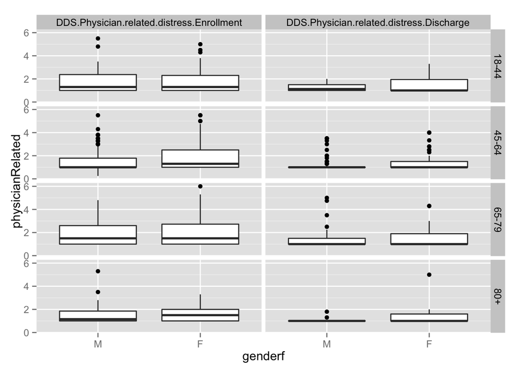

```r
dataframe %>% mutate(id=row_number()) %>%
  gather(admitdischarge,physicianRelated,c(DDS.Physician.related.distress.Enrollment,DDS.Physician.related.distress.Discharge)) %>%
  mutate(agef=cut(age,breaks=c(17,44,64,79,95),labels=c("18-44","45-64","65-79","80+")))->mutatea
  mutatea %>% ggplot(aes(x=genderf,y=physicianRelated))+geom_boxplot()+facet_grid(agef~admitdischarge)
```

spaghetti plot

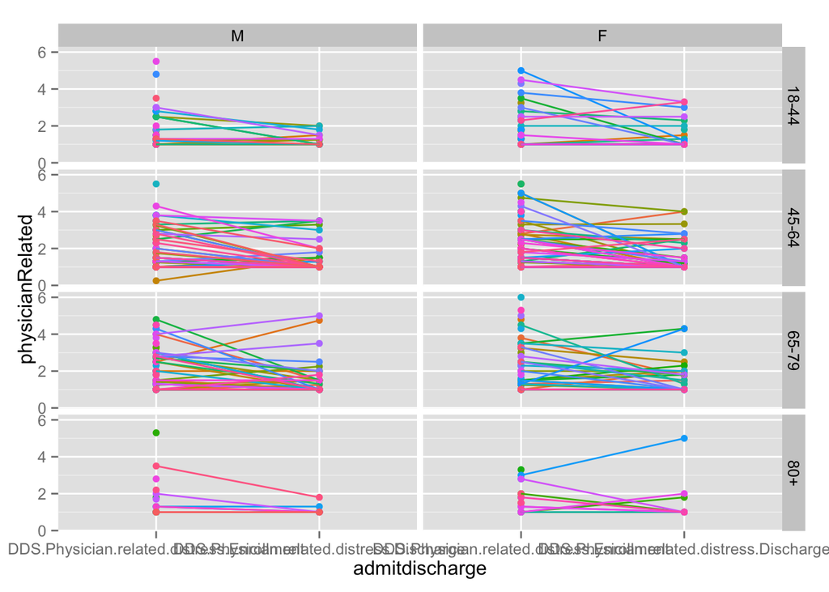

```r
mutatea %>% ggplot(aes(x=admitdischarge,y=physicianRelated,group=id,color=factor(id))) + geom_point() + geom_line() + facet_grid(agef~genderf)+guides(color=F)
```

this plot shows treatment effects as most of the lines go down

2c.Change in QoL index (Regimen related distress)

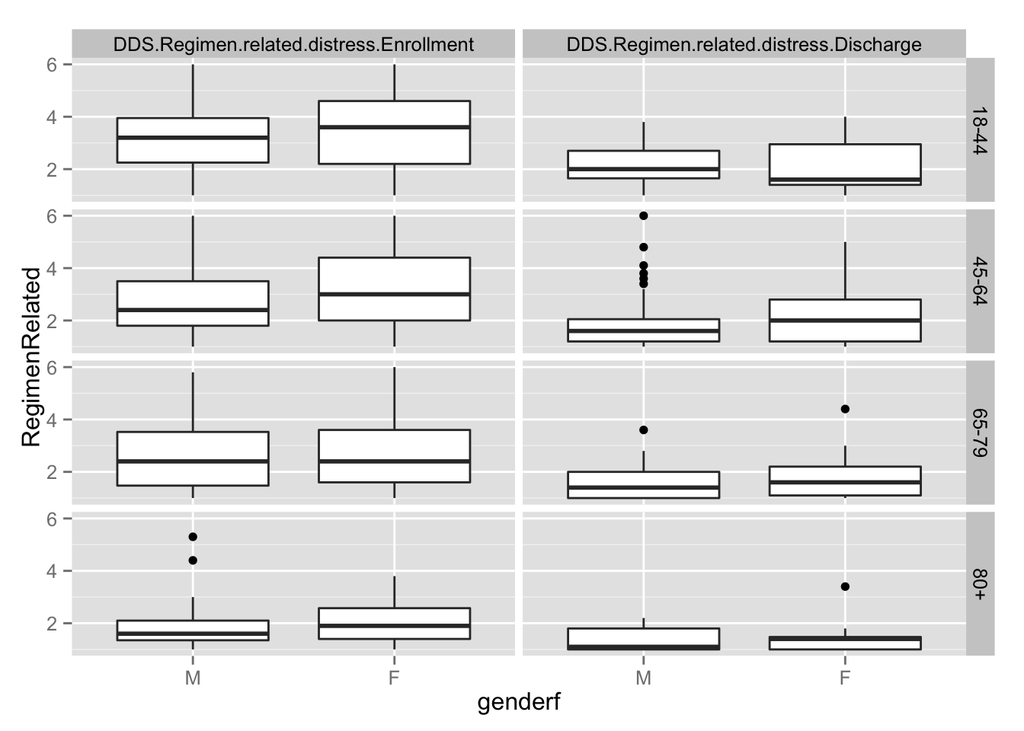

```r
dataframe %>% gather(admitdischarge,RegimenRelated,c(DDS.Regimen.related.distress.Enrollment,DDS.Regimen.related.distress.Discharge)) %>% mutate(agef=cut(age,breaks=c(17,44,64,79,95),labels=c("18-44","45-64","65-79","80+"))) %>% ggplot(aes(x=genderf,y=RegimenRelated))+geom_boxplot()+facet_grid(agef~admitdischarge)
```

-Both female and male patients across all age groups displace substentically lower discharged Regimen related distress score! -among them, both male and female patients in age group 80+ have the lowest admit and discharged Regimen related distress score -no gender effects are observed since the changes in admit and discharged scores are similar for both male and female

2c.Change in QoL index (Interpersonal distress)

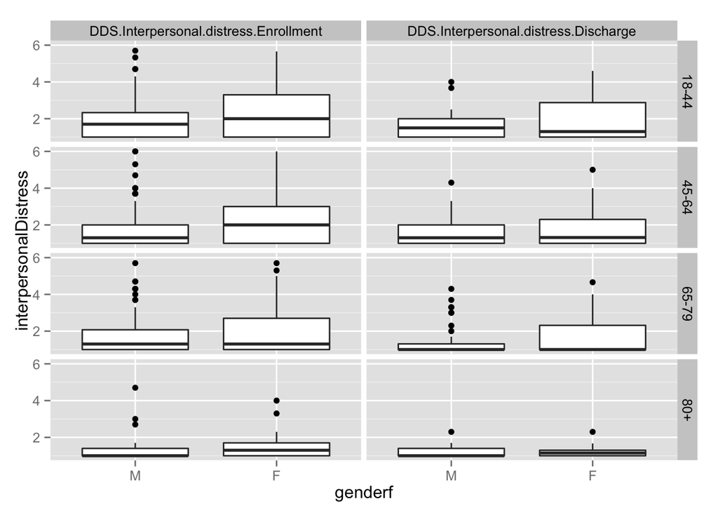

```r
dataframe %>% gather(admitdischarge,interpersonalDistress,c(DDS.Interpersonal.distress.Enrollment,DDS.Interpersonal.distress.Discharge)) %>%
  mutate(agef=cut(age,breaks=c(17,44,64,79,95),labels=c("18-44","45-64","65-79","80+"))) %>%
  ggplot(aes(x=genderf,y=interpersonalDistress))+geom_boxplot()+facet_grid(agef~admitdischarge)
```

spaagetti plot for the data

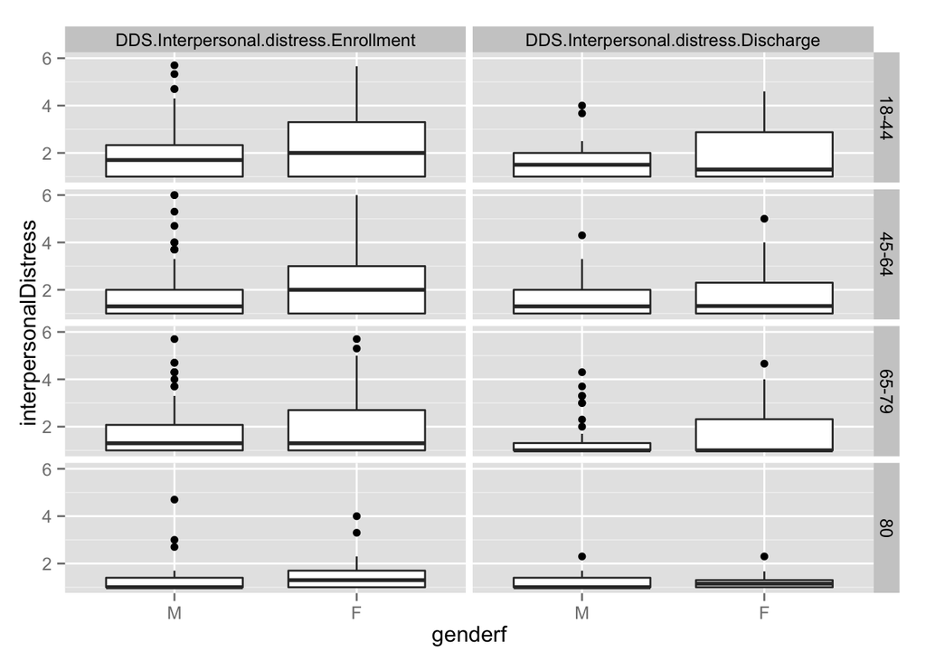

```r
dataframe %>% mutate(id=row_number()) %>% gather(admitdischarge,interpersonalDistress,c(DDS.Interpersonal.distress.Enrollment,DDS.Interpersonal.distress.Discharge)) %>%
  mutate(agef=cut(age,breaks=c(17,44,64,79,95),
                  labels=c("18-44","45-64","65-79","80")))->mutatea
  mutatea %>% ggplot(aes(x=genderf,y=interpersonalDistress))+geom_boxplot()+facet_grid(agef~admitdischarge)
```

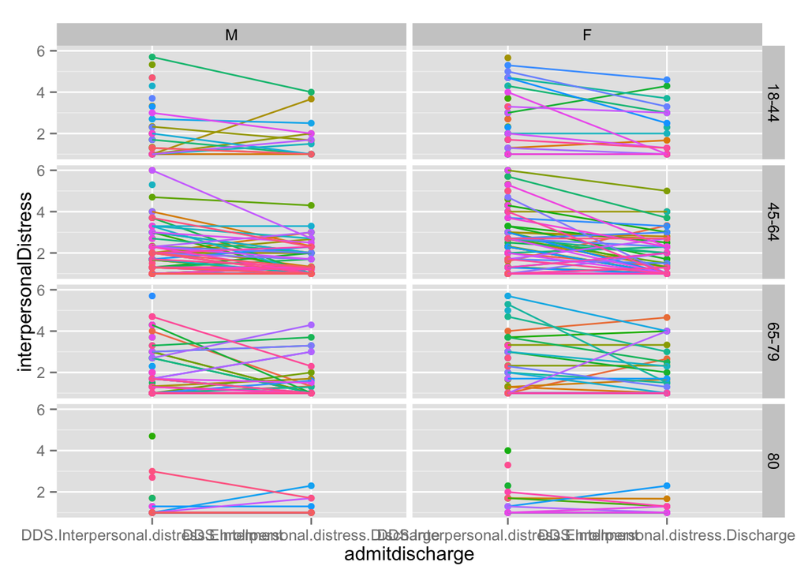

```r
  mutatea %>% ggplot(aes(x=admitdischarge,y=interpersonalDistress,group=id,color=factor(id)))+geom_point()+geom_line()+facet_grid(agef~genderf)+guides(color=F)
```

show treatment effect - line goes down